# Lab 1: Power Converter Circuit Simulation

Andrew Phillips

```python
import matplotlib.pyplot as plt
```

Initial idealized circuit:

[figure not shown]

1. The output current and voltages are constant, so they have a 10A and 10V peak/average respectively. The input current has a peak of 10A and an average of 1A. The voltage across the current source has a peak of 90V and an average of 0.

[figure not shown]

2. There is no ripple on any of the waveforms in this idealized circuit.
3. The resistor dissipates power, while the voltage source and current source supply power.

Added inductor circuit:

[figure not shown]

4. On start up it takes a while for the output current, output voltage, and input current to reach their steady state values. There is also ripple across all the waveforms due to the inductor not being an ideal lossless component (as the inductor cannot instantaneously change current values). The voltage across the inductor is initially net positive as the inductor is charging and then becomes net zero after the inductor reaches steady state.

[figure not shown]

Added capacitor circuit:

[figure not shown]

9. There is far less ripple in the current after the capacitor than before. I would consider the current before the capacitor to have large ripple characteristics, while the current after the capacitor has low ripple characteristics. This makes sense, as the capacitor can help supply the output load when the load is disconnected from the input source, smoothing out the waveform.

Buck converter with type 1 switch cell:

[figure not shown]

10. The block above can be approximated by an ideal transformer, as both blocks accomplish a voltage step down from the input to the output of the circuit. Both components are modelled as lossless, so the components accomplish the same step down (although with AC for the transformer and DC for the switch cell).

[figure not shown]

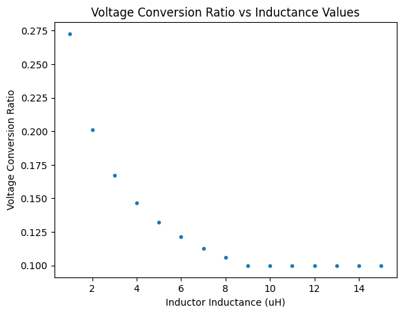

```python
input_voltage = 100 #V
inductances = [1,2,3,4,5,6,7,8,9,10,11,12,13,14,15]
output_voltages = [27.26,20.12,16.74,14.66,13.21,12.13,11.28,10.58,10.01,9.99,9.99,9.99,9.99,9.99,9.99]
voltage_ratios = []
for voltage in output_voltages:
    ratio = voltage/input_voltage
    voltage_ratios.append(ratio)

plt.plot(inductances,voltage_ratios, '.')
plt.xlabel("Inductor Inductance (uH)")
plt.ylabel("Voltage Conversion Ratio")
plt.title("Voltage Conversion Ratio vs Inductance Values")
```

[figure not shown]

The boost waveforms have a similar behavior to the buck converter, with the output voltage and currents being stepped up instead of down for the buck converter. An increased duty cycle still increases the output voltage, although above the input voltage for the boost converter. Both converters still have a similar transient behavior before reaching steady state.

15. The voltage conversion ratio for D=50% 199.39/100 = 1.9937, or ~2.

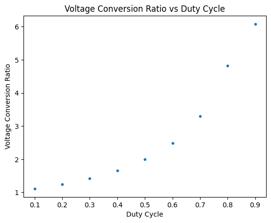

```python
#16
input_voltage = 100
duty_cycles = [0.1,0.2,0.3,0.4,0.5,0.6,0.7,0.8,0.9]
output_voltages = [111.09,124.93,142.70,166.36,199.39,248.72,330.16,481.92,607.93]

voltage_ratios = []
for voltage in output_voltages:
    ratio = voltage/input_voltage
    voltage_ratios.append(ratio)

plt.plot(duty_cycles,voltage_ratios, '.')
plt.xlabel("Duty Cycle")
plt.ylabel("Voltage Conversion Ratio")
plt.title("Voltage Conversion Ratio vs Duty Cycle")
```